# Assignment 2

2024-10-30

Group 3:Julian Janisch, Hanka Jankovicova, Livia Miclaus, Sofiia Selimova, Bence Zsolt Vízvári

## 1. Task

Our main goal is to predict customer churn. In this first task we read the data into R, take a look at our data structure, check missing data, remove irrelevant variables and convert categorical variables into factors.

Let us begin by loading important libraries:

```
## For more information please visit:
```

```
## https://majkamichal.github.io/naivebayes/
```

We read the data into a variable named bankchurners:

```r
bankchurners <- read.csv("BankChurners-1.csv", sep =",", header = TRUE)
```

We take a closer look at our data:

```r
head(bankchurners)
```

```
##   CLIENTNUM    Attrition_Flag Customer_Age Gender Dependent_count
## 1 768805383 Existing Customer           45      M               3
## 2 818770008 Existing Customer           49      F               5
## 3 713982108 Existing Customer           51      M               3
## 4 769911858 Existing Customer           40      F               4
## 5 709106358 Existing Customer           40      M               3
## 6 713061558 Existing Customer           44      M               2
##   Education_Level Marital_Status Income_Category Card_Category Months_on_book
## 1     High School        Married     $60K - $80K          Blue             39
## 2        Graduate         Single  Less than $40K          Blue             44
## 3        Graduate        Married    $80K - $120K          Blue             36
## 4     High School        Unknown  Less than $40K          Blue             34
## 5      Uneducated        Married     $60K - $80K          Blue             21
## 6        Graduate        Married     $40K - $60K          Blue             36
##   Total_Relationship_Count Months_Inactive_12_mon Contacts_Count_12_mon
```

[output cut: 34 more lines]

```r
str(bankchurners)
```

```
## 'data.frame':    10127 obs. of  23 variables:
##  $ CLIENTNUM                                                                                                                         : int  768805383 818770008 713982108 769911858 709106358 713061558 810347208 818906208 710930508 719661558 ...
##  $ Attrition_Flag                                                                                                                    : chr  "Existing Customer" "Existing Customer" "Existing Customer" "Existing Customer" ...
##  $ Customer_Age                                                                                                                      : int  45 49 51 40 40 44 51 32 37 48 ...
##  $ Gender                                                                                                                            : chr  "M" "F" "M" "F" ...
##  $ Dependent_count                                                                                                                   : int  3 5 3 4 3 2 4 0 3 2 ...
##  $ Education_Level                                                                                                                   : chr  "High School" "Graduate" "Graduate" "High School" ...
##  $ Marital_Status                                                                                                                    : chr  "Married" "Single" "Married" "Unknown" ...
##  $ Income_Category                                                                                                                   : chr  "$60K - $80K" "Less than $40K" "$80K - $120K" "Less than $40K" ...
##  $ Card_Category                                                                                                                     : chr  "Blue" "Blue" "Blue" "Blue" ...
##  $ Months_on_book                                                                                                                    : int  39 44 36 34 21 36 46 27 36 36 ...
##  $ Total_Relationship_Count                                                                                                          : int  5 6 4 3 5 3 6 2 5 6 ...
##  $ Months_Inactive_12_mon                                                                                                            : int  1 1 1 4 1 1 1 2 2 3 ...
##  $ Contacts_Count_12_mon                                                                                                             : int  3 2 0 1 0 2 3 2 0 3 ...
##  $ Credit_Limit                                                                                                                      : num  12691 8256 3418 3313 4716 ...
##  $ Total_Revolving_Bal                                                                                                               : int  777 864 0 2517 0 1247 2264 1396 2517 1677 ...
##  $ Avg_Open_To_Buy                                                                                                                   : num  11914 7392 3418 796 4716 ...
##  $ Total_Amt_Chng_Q4_Q1                                                                                                              : num  1.33 1.54 2.59 1.41 2.17 ...
##  $ Total_Trans_Amt                                                                                                                   : int  1144 1291 1887 1171 816 1088 1330 1538 1350 1441 ...
##  $ Total_Trans_Ct                                                                                                                    : int  42 33 20 20 28 24 31 36 24 32 ...
##  $ Total_Ct_Chng_Q4_Q1                                                                                                               : num  1.62 3.71 2.33 2.33 2.5 ...
##  $ Avg_Utilization_Ratio                                                                                                             : num  0.061 0.105 0 0.76 0 0.311 0.066 0.048 0.113 0.144 ...
##  $ Naive_Bayes_Classifier_Attrition_Flag_Card_Category_Contacts_Count_12_mon_Dependent_count_Education_Level_Months_Inactive_12_mon_1: num  9.34e-05 5.69e-05 2.11e-05 1.34e-04 2.17e-05 ...
##  $ Naive_Bayes_Classifier_Attrition_Flag_Card_Category_Contacts_Count_12_mon_Dependent_count_Education_Level_Months_Inactive_12_mon_2: num  1 1 1 1 1 ...
```

```r
summary(bankchurners)
```

```
##    CLIENTNUM         Attrition_Flag      Customer_Age      Gender
##  Min.   :708082083   Length:10127       Min.   :26.00   Length:10127
##  1st Qu.:713036770   Class :character   1st Qu.:41.00   Class :character
##  Median :717926358   Mode  :character   Median :46.00   Mode  :character
##  Mean   :739177606                      Mean   :46.33
##  3rd Qu.:773143533                      3rd Qu.:52.00
##  Max.   :828343083                      Max.   :73.00
##  Dependent_count Education_Level    Marital_Status     Income_Category
##  Min.   :0.000   Length:10127       Length:10127       Length:10127
##  1st Qu.:1.000   Class :character   Class :character   Class :character
##  Median :2.000   Mode  :character   Mode  :character   Mode  :character
##  Mean   :2.346
##  3rd Qu.:3.000
##  Max.   :5.000
##  Card_Category      Months_on_book  Total_Relationship_Count
##  Length:10127       Min.   :13.00   Min.   :1.000
##  Class :character   1st Qu.:31.00   1st Qu.:3.000
##  Mode  :character   Median :36.00   Median :4.000
##                     Mean   :35.93   Mean   :3.813
##                     3rd Qu.:40.00   3rd Qu.:5.000
##                     Max.   :56.00   Max.   :6.000
##  Months_Inactive_12_mon Contacts_Count_12_mon  Credit_Limit
##  Min.   :0.000          Min.   :0.000         Min.   : 1438
##  1st Qu.:2.000          1st Qu.:2.000         1st Qu.: 2555
##  Median :2.000          Median :2.000         Median : 4549
##  Mean   :2.341          Mean   :2.455         Mean   : 8632
##  3rd Qu.:3.000          3rd Qu.:3.000         3rd Qu.:11068
##  Max.   :6.000          Max.   :6.000         Max.   :34516
##  Total_Revolving_Bal Avg_Open_To_Buy Total_Amt_Chng_Q4_Q1 Total_Trans_Amt
##  Min.   :   0        Min.   :    3   Min.   :0.0000       Min.   :  510
##  1st Qu.: 359        1st Qu.: 1324   1st Qu.:0.6310       1st Qu.: 2156
##  Median :1276        Median : 3474   Median :0.7360       Median : 3899
##  Mean   :1163        Mean   : 7469   Mean   :0.7599       Mean   : 4404
##  3rd Qu.:1784        3rd Qu.: 9859   3rd Qu.:0.8590       3rd Qu.: 4741
##  Max.   :2517        Max.   :34516   Max.   :3.3970       Max.   :18484
##  Total_Trans_Ct   Total_Ct_Chng_Q4_Q1 Avg_Utilization_Ratio
##  Min.   : 10.00   Min.   :0.0000      Min.   :0.0000
##  1st Qu.: 45.00   1st Qu.:0.5820      1st Qu.:0.0230
##  Median : 67.00   Median :0.7020      Median :0.1760
##  Mean   : 64.86   Mean   :0.7122      Mean   :0.2749
##  3rd Qu.: 81.00   3rd Qu.:0.8180      3rd Qu.:0.5030
##  Max.   :139.00   Max.   :3.7140      Max.   :0.9990
##  Naive_Bayes_Classifier_Attrition_Flag_Card_Category_Contacts_Count_12_mon_Dependent_count_Education_Level_Months_Inactive_12_mon_1
##  Min.   :0.0000077
##  1st Qu.:0.0000990
##  Median :0.0001815
##  Mean   :0.1599975
##  3rd Qu.:0.0003373
##  Max.   :0.9995800
##  Naive_Bayes_Classifier_Attrition_Flag_Card_Category_Contacts_Count_12_mon_Dependent_count_Education_Level_Months_Inactive_12_mon_2
##  Min.   :0.00042
##  1st Qu.:0.99966
##  Median :0.99982
##  Mean   :0.84000
##  3rd Qu.:0.99990
##  Max.   :0.99999
```

We can observe the different data types that we encounter: integer, chraracter and numerical. We can also observe that Attrition_Flag is the variable that we are mostly interested in. We can also see that some variables need to be converted into factors.

```r
# check for missing data
colSums(is.na(bankchurners))
```

```
##                                                                                                                          CLIENTNUM
##                                                                                                                                  0
##                                                                                                                     Attrition_Flag
##                                                                                                                                  0
##                                                                                                                       Customer_Age
##                                                                                                                                  0
##                                                                                                                             Gender
##                                                                                                                                  0
##                                                                                                                    Dependent_count
##                                                                                                                                  0
##                                                                                                                    Education_Level
##                                                                                                                                  0
##                                                                                                                     Marital_Status
##                                                                                                                                  0
##                                                                                                                    Income_Category
##                                                                                                                                  0
##                                                                                                                      Card_Category
##                                                                                                                                  0
##                                                                                                                     Months_on_book
##                                                                                                                                  0
##                                                                                                           Total_Relationship_Count
##                                                                                                                                  0
##                                                                                                             Months_Inactive_12_mon
##                                                                                                                                  0
##                                                                                                              Contacts_Count_12_mon
##                                                                                                                                  0
##                                                                                                                       Credit_Limit
##                                                                                                                                  0
##                                                                                                                Total_Revolving_Bal
##                                                                                                                                  0
```

[output cut: 16 more lines]

```r
names(bankchurners)
```

```
##  [1] "CLIENTNUM"
##  [2] "Attrition_Flag"
##  [3] "Customer_Age"
##  [4] "Gender"
##  [5] "Dependent_count"
##  [6] "Education_Level"
##  [7] "Marital_Status"
##  [8] "Income_Category"
##  [9] "Card_Category"
## [10] "Months_on_book"
## [11] "Total_Relationship_Count"
## [12] "Months_Inactive_12_mon"
## [13] "Contacts_Count_12_mon"
## [14] "Credit_Limit"
## [15] "Total_Revolving_Bal"
## [16] "Avg_Open_To_Buy"
## [17] "Total_Amt_Chng_Q4_Q1"
## [18] "Total_Trans_Amt"
## [19] "Total_Trans_Ct"
## [20] "Total_Ct_Chng_Q4_Q1"
## [21] "Avg_Utilization_Ratio"
## [22] "Naive_Bayes_Classifier_Attrition_Flag_Card_Category_Contacts_Count_12_mon_Dependent_count_Education_Level_Months_Inactive_12_mon_1"
## [23] "Naive_Bayes_Classifier_Attrition_Flag_Card_Category_Contacts_Count_12_mon_Dependent_count_Education_Level_Months_Inactive_12_mon_2"
```

We have no missing data.

We remove unnecessary variables, such as ClientNUM and synthetic features, to reduce noise and improve model performance:

```r
# remove three unnecassary variables
bankchurners <- bankchurners[, -c(1,22,23)]
str(bankchurners)
```

```
## 'data.frame':    10127 obs. of  20 variables:
##  $ Attrition_Flag          : chr  "Existing Customer" "Existing Customer" "Existing Customer" "Existing Customer" ...
##  $ Customer_Age            : int  45 49 51 40 40 44 51 32 37 48 ...
##  $ Gender                  : chr  "M" "F" "M" "F" ...
##  $ Dependent_count         : int  3 5 3 4 3 2 4 0 3 2 ...
##  $ Education_Level         : chr  "High School" "Graduate" "Graduate" "High School" ...
##  $ Marital_Status          : chr  "Married" "Single" "Married" "Unknown" ...
##  $ Income_Category         : chr  "$60K - $80K" "Less than $40K" "$80K - $120K" "Less than $40K" ...
##  $ Card_Category           : chr  "Blue" "Blue" "Blue" "Blue" ...
##  $ Months_on_book          : int  39 44 36 34 21 36 46 27 36 36 ...
##  $ Total_Relationship_Count: int  5 6 4 3 5 3 6 2 5 6 ...
##  $ Months_Inactive_12_mon  : int  1 1 1 4 1 1 1 2 2 3 ...
##  $ Contacts_Count_12_mon   : int  3 2 0 1 0 2 3 2 0 3 ...
##  $ Credit_Limit            : num  12691 8256 3418 3313 4716 ...
##  $ Total_Revolving_Bal     : int  777 864 0 2517 0 1247 2264 1396 2517 1677 ...
##  $ Avg_Open_To_Buy         : num  11914 7392 3418 796 4716 ...
##  $ Total_Amt_Chng_Q4_Q1    : num  1.33 1.54 2.59 1.41 2.17 ...
##  $ Total_Trans_Amt         : int  1144 1291 1887 1171 816 1088 1330 1538 1350 1441 ...
##  $ Total_Trans_Ct          : int  42 33 20 20 28 24 31 36 24 32 ...
##  $ Total_Ct_Chng_Q4_Q1     : num  1.62 3.71 2.33 2.33 2.5 ...
##  $ Avg_Utilization_Ratio   : num  0.061 0.105 0 0.76 0 0.311 0.066 0.048 0.113 0.144 ...
```

We convert categorical variables into factors:

```r
# transform categorical variables into factors
bankchurners$Attrition_Flag <- factor(bankchurners$Attrition_Flag)
bankchurners$Gender <- factor(bankchurners$Gender)
bankchurners$Education_Level <- factor(bankchurners$Education_Level)
bankchurners$Marital_Status <- factor(bankchurners$Marital_Status)
bankchurners$Income_Category <- factor(bankchurners$Income_Category)
bankchurners$Card_Category <- factor(bankchurners$Card_Category)
str(bankchurners)
```

```
## 'data.frame':    10127 obs. of  20 variables:
##  $ Attrition_Flag          : Factor w/ 2 levels "Attrited Customer",..: 2 2 2 2 2 2 2 2 2 2 ...
##  $ Customer_Age            : int  45 49 51 40 40 44 51 32 37 48 ...
##  $ Gender                  : Factor w/ 2 levels "F","M": 2 1 2 1 2 2 2 2 2 2 ...
##  $ Dependent_count         : int  3 5 3 4 3 2 4 0 3 2 ...
##  $ Education_Level         : Factor w/ 7 levels "College","Doctorate",..: 4 3 3 4 6 3 7 4 6 3 ...
##  $ Marital_Status          : Factor w/ 4 levels "Divorced","Married",..: 2 3 2 4 2 2 2 4 3 3 ...
##  $ Income_Category         : Factor w/ 6 levels "$120K +","$40K - $60K",..: 3 5 4 5 3 2 1 3 3 4 ...
##  $ Card_Category           : Factor w/ 4 levels "Blue","Gold",..: 1 1 1 1 1 1 2 4 1 1 ...
##  $ Months_on_book          : int  39 44 36 34 21 36 46 27 36 36 ...
##  $ Total_Relationship_Count: int  5 6 4 3 5 3 6 2 5 6 ...
##  $ Months_Inactive_12_mon  : int  1 1 1 4 1 1 1 2 2 3 ...
##  $ Contacts_Count_12_mon   : int  3 2 0 1 0 2 3 2 0 3 ...
##  $ Credit_Limit            : num  12691 8256 3418 3313 4716 ...
##  $ Total_Revolving_Bal     : int  777 864 0 2517 0 1247 2264 1396 2517 1677 ...
##  $ Avg_Open_To_Buy         : num  11914 7392 3418 796 4716 ...
##  $ Total_Amt_Chng_Q4_Q1    : num  1.33 1.54 2.59 1.41 2.17 ...
##  $ Total_Trans_Amt         : int  1144 1291 1887 1171 816 1088 1330 1538 1350 1441 ...
##  $ Total_Trans_Ct          : int  42 33 20 20 28 24 31 36 24 32 ...
##  $ Total_Ct_Chng_Q4_Q1     : num  1.62 3.71 2.33 2.33 2.5 ...
##  $ Avg_Utilization_Ratio   : num  0.061 0.105 0 0.76 0 0.311 0.066 0.048 0.113 0.144 ...
```

We check if the factors are ordered intuitively or not:

```r
# take a look at the order of the levels
levels(bankchurners$Attrition_Flag)
```

```
## [1] "Attrited Customer" "Existing Customer"
```

```r
levels(bankchurners$Gender)
```

```
## [1] "F" "M"
```

```r
levels(bankchurners$Education_Level)
```

```
## [1] "College"       "Doctorate"     "Graduate"      "High School"
## [5] "Post-Graduate" "Uneducated"    "Unknown"
```

```r
levels(bankchurners$Marital_Status)
```

```
## [1] "Divorced" "Married"  "Single"   "Unknown"
```

```r
levels(bankchurners$Income_Category)
```

```
## [1] "$120K +"        "$40K - $60K"    "$60K - $80K"    "$80K - $120K"
## [5] "Less than $40K" "Unknown"
```

```r
levels(bankchurners$Card_Category)
```

```
## [1] "Blue"     "Gold"     "Platinum" "Silver"
```

Based on the observations, the levels are not in a logical order, so we may need to reorder them for better interpretation.

```r
# order the levels in a more intuitive way
bankchurners$Attrition_Flag <- factor(bankchurners$Attrition_Flag,
                                      levels = c("Existing Customer",
                                                 "Attrited Customer"))

bankchurners$Education_Level <- factor(bankchurners$Education_Level,
                                       levels = c("Uneducated", "High School",
                                                  "College", "Graduate",
                                                  "Post-Graduate",
                                                  "Doctorate", "Unknown"))

bankchurners$Marital_Status <- factor(bankchurners$Marital_Status,
                                      levels = c("Single", "Married",
                                                 "Divorced", "Unknown"))

bankchurners$Income_Category <- factor(bankchurners$Income_Category,
                                       levels = c("Less than $40K",
                                                  "$40K - $60K",
                                                  "$60K - $80K",
                                                  "$80K - $120K",
                                                  "$120K +", "Unknown"))

bankchurners$Card_Category <- factor(bankchurners$Card_Category,
                                     levels = c("Blue", "Silver",
                                                "Gold", "Platinum"))

str(bankchurners)
```

```
## 'data.frame':    10127 obs. of  20 variables:
##  $ Attrition_Flag          : Factor w/ 2 levels "Existing Customer",..: 1 1 1 1 1 1 1 1 1 1 ...
##  $ Customer_Age            : int  45 49 51 40 40 44 51 32 37 48 ...
##  $ Gender                  : Factor w/ 2 levels "F","M": 2 1 2 1 2 2 2 2 2 2 ...
##  $ Dependent_count         : int  3 5 3 4 3 2 4 0 3 2 ...
##  $ Education_Level         : Factor w/ 7 levels "Uneducated","High School",..: 2 4 4 2 1 4 7 2 1 4 ...
##  $ Marital_Status          : Factor w/ 4 levels "Single","Married",..: 2 1 2 4 2 2 2 4 1 1 ...
##  $ Income_Category         : Factor w/ 6 levels "Less than $40K",..: 3 1 4 1 3 2 5 3 3 4 ...
##  $ Card_Category           : Factor w/ 4 levels "Blue","Silver",..: 1 1 1 1 1 1 3 2 1 1 ...
##  $ Months_on_book          : int  39 44 36 34 21 36 46 27 36 36 ...
##  $ Total_Relationship_Count: int  5 6 4 3 5 3 6 2 5 6 ...
##  $ Months_Inactive_12_mon  : int  1 1 1 4 1 1 1 2 2 3 ...
##  $ Contacts_Count_12_mon   : int  3 2 0 1 0 2 3 2 0 3 ...
##  $ Credit_Limit            : num  12691 8256 3418 3313 4716 ...
##  $ Total_Revolving_Bal     : int  777 864 0 2517 0 1247 2264 1396 2517 1677 ...
##  $ Avg_Open_To_Buy         : num  11914 7392 3418 796 4716 ...
##  $ Total_Amt_Chng_Q4_Q1    : num  1.33 1.54 2.59 1.41 2.17 ...
##  $ Total_Trans_Amt         : int  1144 1291 1887 1171 816 1088 1330 1538 1350 1441 ...
##  $ Total_Trans_Ct          : int  42 33 20 20 28 24 31 36 24 32 ...
##  $ Total_Ct_Chng_Q4_Q1     : num  1.62 3.71 2.33 2.33 2.5 ...
##  $ Avg_Utilization_Ratio   : num  0.061 0.105 0 0.76 0 0.311 0.066 0.048 0.113 0.144 ...
```

```r
# Check the new order of levels after reordering
levels(bankchurners$Attrition_Flag)
```

```
## [1] "Existing Customer" "Attrited Customer"
```

```r
levels(bankchurners$Gender)
```

```
## [1] "F" "M"
```

```r
levels(bankchurners$Education_Level)
```

```
## [1] "Uneducated"    "High School"   "College"       "Graduate"
## [5] "Post-Graduate" "Doctorate"     "Unknown"
```

```r
levels(bankchurners$Marital_Status)
```

```
## [1] "Single"   "Married"  "Divorced" "Unknown"
```

```r
levels(bankchurners$Income_Category)
```

```
## [1] "Less than $40K" "$40K - $60K"    "$60K - $80K"    "$80K - $120K"
## [5] "$120K +"        "Unknown"
```

```r
levels(bankchurners$Card_Category)
```

```
## [1] "Blue"     "Silver"   "Gold"     "Platinum"
```

After completing these steps, let’s review the summary statistics of the data:

```r
# take a look at the summary
summary(bankchurners)
```

```
##            Attrition_Flag  Customer_Age   Gender   Dependent_count
##  Existing Customer:8500   Min.   :26.00   F:5358   Min.   :0.000
##  Attrited Customer:1627   1st Qu.:41.00   M:4769   1st Qu.:1.000
##                           Median :46.00            Median :2.000
##                           Mean   :46.33            Mean   :2.346
##                           3rd Qu.:52.00            3rd Qu.:3.000
##                           Max.   :73.00            Max.   :5.000
##
##       Education_Level  Marital_Status       Income_Category  Card_Category
##  Uneducated   :1487   Single  :3943   Less than $40K:3561   Blue    :9436
##  High School  :2013   Married :4687   $40K - $60K   :1790   Silver  : 555
##  College      :1013   Divorced: 748   $60K - $80K   :1402   Gold    : 116
##  Graduate     :3128   Unknown : 749   $80K - $120K  :1535   Platinum:  20
##  Post-Graduate: 516                   $120K +       : 727
##  Doctorate    : 451                   Unknown       :1112
##  Unknown      :1519
##  Months_on_book  Total_Relationship_Count Months_Inactive_12_mon
##  Min.   :13.00   Min.   :1.000            Min.   :0.000
##  1st Qu.:31.00   1st Qu.:3.000            1st Qu.:2.000
##  Median :36.00   Median :4.000            Median :2.000
##  Mean   :35.93   Mean   :3.813            Mean   :2.341
##  3rd Qu.:40.00   3rd Qu.:5.000            3rd Qu.:3.000
##  Max.   :56.00   Max.   :6.000            Max.   :6.000
##
##  Contacts_Count_12_mon  Credit_Limit   Total_Revolving_Bal Avg_Open_To_Buy
##  Min.   :0.000         Min.   : 1438   Min.   :   0        Min.   :    3
##  1st Qu.:2.000         1st Qu.: 2555   1st Qu.: 359        1st Qu.: 1324
##  Median :2.000         Median : 4549   Median :1276        Median : 3474
##  Mean   :2.455         Mean   : 8632   Mean   :1163        Mean   : 7469
##  3rd Qu.:3.000         3rd Qu.:11068   3rd Qu.:1784        3rd Qu.: 9859
##  Max.   :6.000         Max.   :34516   Max.   :2517        Max.   :34516
##
##  Total_Amt_Chng_Q4_Q1 Total_Trans_Amt Total_Trans_Ct   Total_Ct_Chng_Q4_Q1
##  Min.   :0.0000       Min.   :  510   Min.   : 10.00   Min.   :0.0000
##  1st Qu.:0.6310       1st Qu.: 2156   1st Qu.: 45.00   1st Qu.:0.5820
##  Median :0.7360       Median : 3899   Median : 67.00   Median :0.7020
##  Mean   :0.7599       Mean   : 4404   Mean   : 64.86   Mean   :0.7122
##  3rd Qu.:0.8590       3rd Qu.: 4741   3rd Qu.: 81.00   3rd Qu.:0.8180
##  Max.   :3.3970       Max.   :18484   Max.   :139.00   Max.   :3.7140
##
##  Avg_Utilization_Ratio
##  Min.   :0.0000
##  1st Qu.:0.0230
##  Median :0.1760
##  Mean   :0.2749
##  3rd Qu.:0.5030
##  Max.   :0.9990
##
```

```r
# calculate the percentage of customers who left the bank
t <- table(bankchurners$Attrition_Flag)
churned_cust <- (t["Attrited Customer"] / (t["Existing Customer"] + t["Attrited Customer"]))
cat("Percentage of churned customers:", churned_cust * 100, "%") # ~ 16.1 %
```

```
## Percentage of churned customers: 16.06596 %
```

Observations:

summary(bankchurners$Attrition_Flag) Only 16% of customers have the churn variable set to 1, indicating a class imbalance. Accuracy can be misleading when the class distribution is unbalanced.

summary(bankchurners$Total_Trans_Amt) The total transaction amount is mainly around $4K, however there is at least one outlier whose transaction amount exceeded $18K

We generate graphs to investigate further relationships:

We plot the relationship between total transaction amount and credit limit:

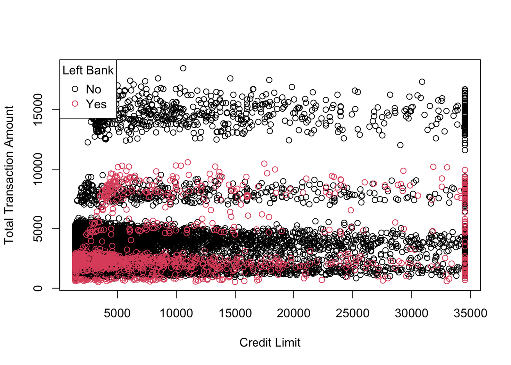

```r
plot(Total_Trans_Amt ~ Credit_Limit,
     col= as.numeric(Attrition_Flag),
     data = bankchurners,
     xlab = "Credit Limit",
     ylab = "Total Transaction Amount")
legend("topleft", title = "Left Bank", pch = 1,
       col = c(1, 2),
       legend= c("No", "Yes"))
```

Observations: It looks like people with a lower transaction amount are more likely to churn

We plot the relationship between attrition flag and gender

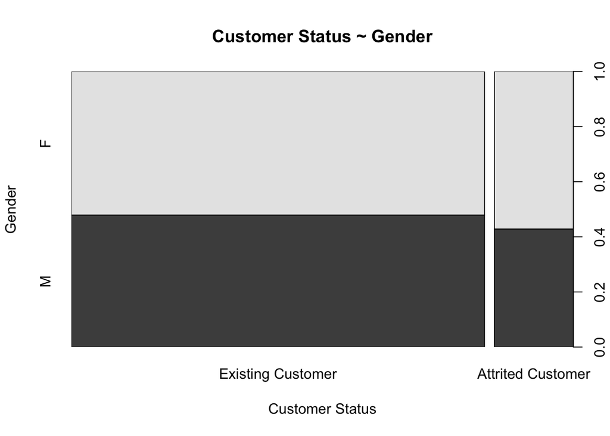

```r
plot(bankchurners$Attrition_Flag, bankchurners$Gender,
     main = "Customer Status ~ Gender",
     xlab = "Customer Status",
     ylab = "Gender")
```

Observations: It looks like women are a little bit more likely to leave the bank

We plot the relationship between churn and total transaction amount (cut off some outliers with ylab):

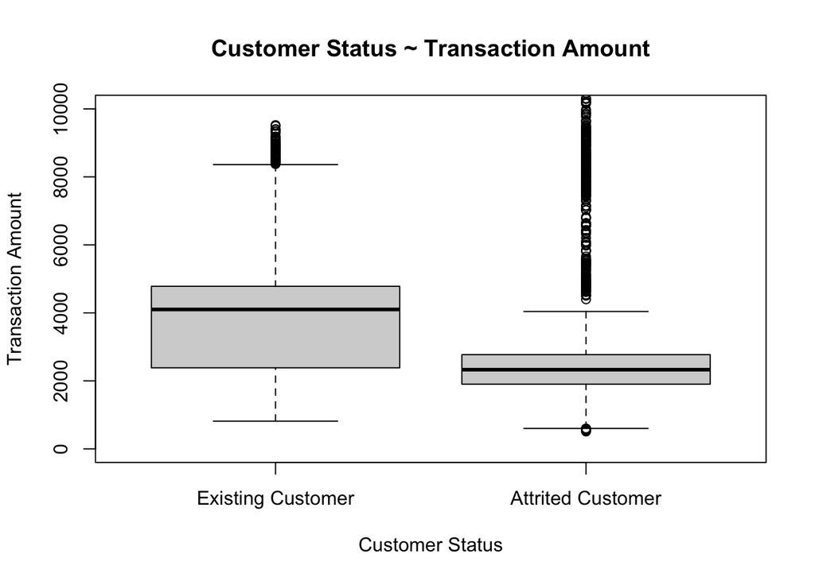

```r
plot(bankchurners$Attrition_Flag, bankchurners$Total_Trans_Amt,
     ylim= c(0,10000),
     main= "Customer Status ~ Transaction Amount",
     xlab= "Customer Status",
     ylab= "Transaction Amount")
```

Observations: According to this boxplot, it seems that customers are more likely to leave the bank when the transaction amount is lower

We plot the relationship between churn and age:

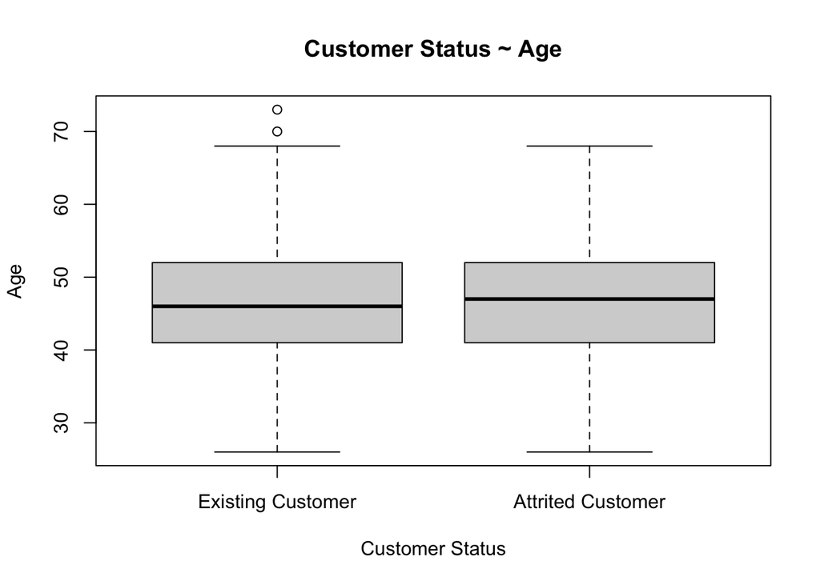

```r
plot(bankchurners$Attrition_Flag, bankchurners$Customer_Age,
     main= "Customer Status ~ Age",
     xlab= "Customer Status",
     ylab= "Age")
```

Observations: There seems to be no relation between the two variables

We plot the relationship between churn and education level:

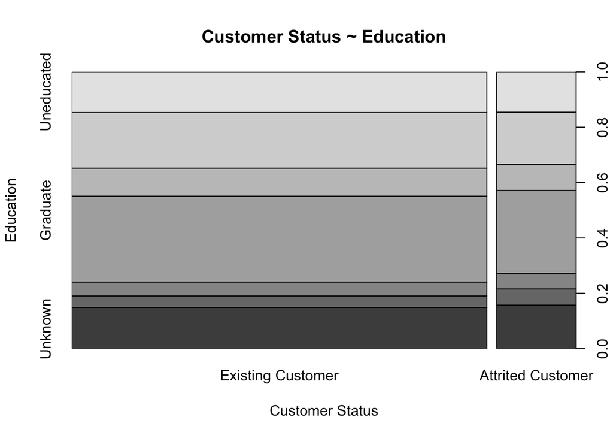

```r
plot(bankchurners$Attrition_Flag, bankchurners$Education_Level,
     main= "Customer Status ~ Education",
     xlab= "Customer Status",
     ylab= "Education")
```

Observations: This plot shows also no significant relationship

We plot the relationship between chrun and Contact Count:

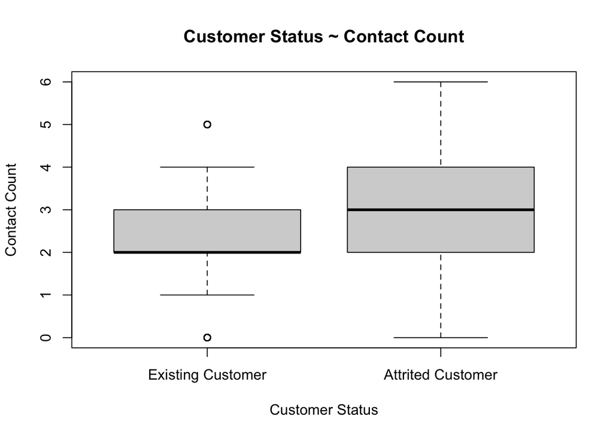

```r
plot(bankchurners$Attrition_Flag, bankchurners$Contacts_Count_12_mon,
     main= "Customer Status ~ Contact Count",
     xlab= "Customer Status",
     ylab= "Contact Count")
```

Observations:This might show some relation, so that people who had more frequent contact ultimately left the bank

## 2. Task

In this task we will split the data into a training set and a test set:

```r
# Set a seed for reproducibility
set.seed(789)

# Create a training index using a random sample of row indices (80% of data)
train_index <- sample(1:nrow(bankchurners), size = 0.8 * nrow(bankchurners), replace = FALSE)

# Split the data into training and testing sets
training_set <- bankchurners[train_index, ]
test_set <- bankchurners[-train_index, ]
```

## 3. Task

In this task we build a logistic regression model to predict churn and identify which variables significantly impact it:

```r
fit_train <- glm(Attrition_Flag ~ .,data = training_set, family = binomial())

fit_train
```

```
##
## Call:  glm(formula = Attrition_Flag ~ ., family = binomial(), data = training_set)
##
## Coefficients:
##                  (Intercept)                  Customer_Age
##                    6.373e+00                    -1.236e-02
##                      GenderM               Dependent_count
##                   -8.863e-01                     1.462e-01
##   Education_LevelHigh School        Education_LevelCollege
##                   -2.497e-02                    -1.987e-02
##      Education_LevelGraduate  Education_LevelPost-Graduate
##                   -1.167e-01                     1.729e-01
##     Education_LevelDoctorate        Education_LevelUnknown
##                    2.484e-01                     2.218e-02
##        Marital_StatusMarried        Marital_StatusDivorced
##                   -5.452e-01                    -1.842e-01
##        Marital_StatusUnknown    Income_Category$40K - $60K
##                    1.955e-02                    -4.435e-02
##   Income_Category$60K - $80K   Income_Category$80K - $120K
##                    1.377e-01                     4.162e-01
##       Income_Category$120K +        Income_CategoryUnknown
##                    8.540e-01                    -6.900e-02
##          Card_CategorySilver             Card_CategoryGold
##                    4.627e-01                     1.344e+00
##        Card_CategoryPlatinum                Months_on_book
##                    8.691e-01                    -3.642e-03
##     Total_Relationship_Count        Months_Inactive_12_mon
##                   -4.520e-01                     5.080e-01
##        Contacts_Count_12_mon                  Credit_Limit
##                    5.139e-01                    -1.812e-05
##          Total_Revolving_Bal               Avg_Open_To_Buy
##                   -9.376e-04                            NA
##         Total_Amt_Chng_Q4_Q1               Total_Trans_Amt
##                   -6.536e-01                     4.615e-04
##               Total_Trans_Ct           Total_Ct_Chng_Q4_Q1
##                   -1.177e-01                    -2.577e+00
##        Avg_Utilization_Ratio
##                   -1.853e-01
##
## Degrees of Freedom: 8100 Total (i.e. Null);  8069 Residual
## Null Deviance:       7123
## Residual Deviance: 3762  AIC: 3826
```

```r
summary(fit_train)
```

```
##
## Call:
## glm(formula = Attrition_Flag ~ ., family = binomial(), data = training_set)
##
## Coefficients: (1 not defined because of singularities)
##                                Estimate Std. Error z value Pr(>|z|)
## (Intercept)                   6.373e+00  4.349e-01  14.652  < 2e-16 ***
## Customer_Age                 -1.236e-02  8.635e-03  -1.431 0.152345
## GenderM                      -8.863e-01  1.626e-01  -5.452 4.97e-08 ***
## Dependent_count               1.462e-01  3.366e-02   4.344 1.40e-05 ***
## Education_LevelHigh School   -2.497e-02  1.474e-01  -0.169 0.865450
## Education_LevelCollege       -1.987e-02  1.782e-01  -0.111 0.911235
## Education_LevelGraduate      -1.167e-01  1.374e-01  -0.849 0.395675
## Education_LevelPost-Graduate  1.729e-01  2.166e-01   0.798 0.424765
## Education_LevelDoctorate      2.484e-01  2.199e-01   1.130 0.258641
## Education_LevelUnknown        2.218e-02  1.573e-01   0.141 0.887888
## Marital_StatusMarried        -5.452e-01  9.413e-02  -5.792 6.95e-09 ***
## Marital_StatusDivorced       -1.842e-01  1.755e-01  -1.049 0.294045
## Marital_StatusUnknown         1.955e-02  1.636e-01   0.119 0.904886
## Income_Category$40K - $60K   -4.435e-02  1.363e-01  -0.325 0.744882
## Income_Category$60K - $80K    1.377e-01  2.080e-01   0.662 0.508052
## Income_Category$80K - $120K   4.162e-01  2.108e-01   1.974 0.048345 *
## Income_Category$120K +        8.540e-01  2.427e-01   3.518 0.000435 ***
## Income_CategoryUnknown       -6.900e-02  1.517e-01  -0.455 0.649164
## Card_CategorySilver           4.627e-01  2.147e-01   2.155 0.031166 *
## Card_CategoryGold             1.344e+00  3.836e-01   3.503 0.000459 ***
## Card_CategoryPlatinum         8.691e-01  8.113e-01   1.071 0.284070
## Months_on_book               -3.642e-03  8.583e-03  -0.424 0.671344
## Total_Relationship_Count     -4.520e-01  3.058e-02 -14.778  < 2e-16 ***
## Months_Inactive_12_mon        5.080e-01  4.245e-02  11.966  < 2e-16 ***
## Contacts_Count_12_mon         5.139e-01  4.079e-02  12.598  < 2e-16 ***
## Credit_Limit                 -1.812e-05  7.636e-06  -2.374 0.017612 *
## Total_Revolving_Bal          -9.376e-04  7.989e-05 -11.736  < 2e-16 ***
## Avg_Open_To_Buy                      NA         NA      NA       NA
## Total_Amt_Chng_Q4_Q1         -6.536e-01  2.139e-01  -3.056 0.002247 **
## Total_Trans_Amt               4.615e-04  2.557e-05  18.048  < 2e-16 ***
## Total_Trans_Ct               -1.177e-01  4.128e-03 -28.504  < 2e-16 ***
## Total_Ct_Chng_Q4_Q1          -2.577e+00  2.078e-01 -12.400  < 2e-16 ***
## Avg_Utilization_Ratio        -1.853e-01  2.749e-01  -0.674 0.500265
## ---
## Signif. codes:  0 '***' 0.001 '**' 0.01 '*' 0.05 '.' 0.1 ' ' 1
##
## (Dispersion parameter for binomial family taken to be 1)
##
##     Null deviance: 7123.0  on 8100  degrees of freedom
## Residual deviance: 3762.5  on 8069  degrees of freedom
## AIC: 3826.5
##
## Number of Fisher Scoring iterations: 6
```

Observations:

The variables which have a significant impact on churn are: GenderM, Dependent_count, Marital_StatusMarried, Income_Category 80K-120K, Income_Category 120K+, Card_CategorySilver, Card_CategoryGold, Total_Relationship_count, Months_Inactive_12_mon, Contacts_Count_12_mon, Credit_Limit, Total_Revolving_Bal,Total_Amt_Chng_Q4_Q1, Total_Trans_Amt, Total_Trans_Ct, Total_Ct_Chng_Q4_Q1

## 4. Task

In this task we perform stepwise model selection using AIC to identify the most significant predictors of churn:

```r
step_train <- step(fit_train, direction = "backward")
```

```
## Start:  AIC=3826.47
## Attrition_Flag ~ Customer_Age + Gender + Dependent_count + Education_Level +
##     Marital_Status + Income_Category + Card_Category + Months_on_book +
##     Total_Relationship_Count + Months_Inactive_12_mon + Contacts_Count_12_mon +
##     Credit_Limit + Total_Revolving_Bal + Avg_Open_To_Buy + Total_Amt_Chng_Q4_Q1 +
##     Total_Trans_Amt + Total_Trans_Ct + Total_Ct_Chng_Q4_Q1 +
##     Avg_Utilization_Ratio
##
##
## Step:  AIC=3826.47
## Attrition_Flag ~ Customer_Age + Gender + Dependent_count + Education_Level +
##     Marital_Status + Income_Category + Card_Category + Months_on_book +
##     Total_Relationship_Count + Months_Inactive_12_mon + Contacts_Count_12_mon +
##     Credit_Limit + Total_Revolving_Bal + Total_Amt_Chng_Q4_Q1 +
##     Total_Trans_Amt + Total_Trans_Ct + Total_Ct_Chng_Q4_Q1 +
##     Avg_Utilization_Ratio
##
##                            Df Deviance    AIC
## - Education_Level           6   3767.3 3819.3
## - Months_on_book            1   3762.7 3824.7
## - Avg_Utilization_Ratio     1   3762.9 3824.9
## <none>                          3762.5 3826.5
## - Customer_Age              1   3764.5 3826.5
## - Credit_Limit              1   3768.2 3830.2
## - Card_Category             3   3776.1 3834.1
## - Total_Amt_Chng_Q4_Q1      1   3772.2 3834.2
## - Income_Category           5   3781.9 3835.9
## - Dependent_count           1   3781.5 3843.5
## - Gender                    1   3793.9 3855.9
## - Marital_Status            3   3800.4 3858.4
## - Months_Inactive_12_mon    1   3907.1 3969.1
## - Total_Revolving_Bal       1   3908.7 3970.7
## - Contacts_Count_12_mon     1   3935.6 3997.6
## - Total_Ct_Chng_Q4_Q1       1   3952.6 4014.6
## - Total_Relationship_Count  1   4001.5 4063.5
## - Total_Trans_Amt           1   4070.9 4132.9
## - Total_Trans_Ct            1   4923.3 4985.3
##
## Step:  AIC=3819.33
## Attrition_Flag ~ Customer_Age + Gender + Dependent_count + Marital_Status +
```

[output cut: 60 more lines]

```
## - Credit_Limit              1   3773.4 3819.4
## - Customer_Age              1   3776.2 3822.2
## - Card_Category             3   3781.6 3823.6
## - Total_Amt_Chng_Q4_Q1      1   3777.6 3823.6
## - Income_Category           5   3787.2 3825.2
## - Dependent_count           1   3787.3 3833.3
## - Gender                    1   3799.6 3845.6
## - Marital_Status            3   3806.1 3848.1
## - Months_Inactive_12_mon    1   3911.7 3957.7
## - Contacts_Count_12_mon     1   3942.7 3988.7
## - Total_Ct_Chng_Q4_Q1       1   3959.8 4005.8
## - Total_Relationship_Count  1   4009.2 4055.2
## - Total_Trans_Amt           1   4078.3 4124.3
## - Total_Revolving_Bal       1   4166.4 4212.4
## - Total_Trans_Ct            1   4933.7 4979.7
```

```r
step_train
```

```
##
## Call:  glm(formula = Attrition_Flag ~ Customer_Age + Gender + Dependent_count +
##     Marital_Status + Income_Category + Card_Category + Total_Relationship_Count +
##     Months_Inactive_12_mon + Contacts_Count_12_mon + Credit_Limit +
##     Total_Revolving_Bal + Total_Amt_Chng_Q4_Q1 + Total_Trans_Amt +
##     Total_Trans_Ct + Total_Ct_Chng_Q4_Q1, family = binomial(),
##     data = training_set)
##
## Coefficients:
##                 (Intercept)                 Customer_Age
##                   6.3384675                   -0.0151567
##                     GenderM              Dependent_count
##                  -0.8871343                    0.1465950
##       Marital_StatusMarried       Marital_StatusDivorced
##                  -0.5449823                   -0.1850441
##       Marital_StatusUnknown   Income_Category$40K - $60K
##                   0.0215855                   -0.0326382
##  Income_Category$60K - $80K  Income_Category$80K - $120K
##                   0.1550041                    0.4333008
##      Income_Category$120K +       Income_CategoryUnknown
##                   0.8662721                   -0.0474037
##         Card_CategorySilver            Card_CategoryGold
##                   0.4631724                    1.3322993
##       Card_CategoryPlatinum     Total_Relationship_Count
##                   0.9424723                   -0.4535464
##      Months_Inactive_12_mon        Contacts_Count_12_mon
##                   0.5031412                    0.5151075
##                Credit_Limit          Total_Revolving_Bal
##                  -0.0000160                   -0.0009801
##        Total_Amt_Chng_Q4_Q1              Total_Trans_Amt
##                  -0.6504738                    0.0004623
##              Total_Trans_Ct          Total_Ct_Chng_Q4_Q1
##                  -0.1177042                   -2.5849018
##
## Degrees of Freedom: 8100 Total (i.e. Null);  8077 Residual
## Null Deviance:       7123
## Residual Deviance: 3768  AIC: 3816
```

```r
summary(step_train)
```

```
##
## Call:
## glm(formula = Attrition_Flag ~ Customer_Age + Gender + Dependent_count +
##     Marital_Status + Income_Category + Card_Category + Total_Relationship_Count +
##     Months_Inactive_12_mon + Contacts_Count_12_mon + Credit_Limit +
##     Total_Revolving_Bal + Total_Amt_Chng_Q4_Q1 + Total_Trans_Amt +
##     Total_Trans_Ct + Total_Ct_Chng_Q4_Q1, family = binomial(),
##     data = training_set)
##
## Coefficients:
##                               Estimate Std. Error z value Pr(>|z|)
## (Intercept)                  6.338e+00  4.172e-01  15.193  < 2e-16 ***
## Customer_Age                -1.516e-02  5.282e-03  -2.870 0.004110 **
## GenderM                     -8.871e-01  1.622e-01  -5.469 4.53e-08 ***
## Dependent_count              1.466e-01  3.351e-02   4.375 1.21e-05 ***
## Marital_StatusMarried       -5.450e-01  9.399e-02  -5.799 6.69e-09 ***
## Marital_StatusDivorced      -1.850e-01  1.755e-01  -1.055 0.291635
## Marital_StatusUnknown        2.159e-02  1.630e-01   0.132 0.894655
## Income_Category$40K - $60K  -3.264e-02  1.358e-01  -0.240 0.810119
## Income_Category$60K - $80K   1.550e-01  2.072e-01   0.748 0.454455
## Income_Category$80K - $120K  4.333e-01  2.100e-01   2.063 0.039088 *
## Income_Category$120K +       8.663e-01  2.423e-01   3.575 0.000351 ***
## Income_CategoryUnknown      -4.740e-02  1.506e-01  -0.315 0.752897
## Card_CategorySilver          4.632e-01  2.148e-01   2.156 0.031066 *
## Card_CategoryGold            1.332e+00  3.839e-01   3.471 0.000519 ***
## Card_CategoryPlatinum        9.425e-01  8.021e-01   1.175 0.239980
## Total_Relationship_Count    -4.535e-01  3.056e-02 -14.841  < 2e-16 ***
## Months_Inactive_12_mon       5.031e-01  4.219e-02  11.925  < 2e-16 ***
## Contacts_Count_12_mon        5.151e-01  4.074e-02  12.645  < 2e-16 ***
## Credit_Limit                -1.600e-05  6.949e-06  -2.302 0.021340 *
## Total_Revolving_Bal         -9.801e-04  5.189e-05 -18.888  < 2e-16 ***
## Total_Amt_Chng_Q4_Q1        -6.505e-01  2.135e-01  -3.046 0.002316 **
## Total_Trans_Amt              4.623e-04  2.548e-05  18.143  < 2e-16 ***
## Total_Trans_Ct              -1.177e-01  4.121e-03 -28.564  < 2e-16 ***
## Total_Ct_Chng_Q4_Q1         -2.585e+00  2.078e-01 -12.440  < 2e-16 ***
## ---
## Signif. codes:  0 '***' 0.001 '**' 0.01 '*' 0.05 '.' 0.1 ' ' 1
##
## (Dispersion parameter for binomial family taken to be 1)
##
##     Null deviance: 7123  on 8100  degrees of freedom
## Residual deviance: 3768  on 8077  degrees of freedom
## AIC: 3816
##
## Number of Fisher Scoring iterations: 6
```

Question: Which variables remain in the final model? Answer: A total of 15 variables:

Customer_Age, Gender, Dependent_count, Marital_Status (Married, Divorced, Unknown), Income_Category ($40K - $60K, $60K - $80K, $80K - $120K, $120K +, Unknown), Card_Category (Silver, Gold, Platinum), Total_Relationship_Count, Months_Inactive_12_mon, Contacts_Count_12_mon, Credit_Limit, Total_Revolving_Bal, Total_Amt_Chng_Q4_Q1, Total_Trans_Amt, Total_Trans_Ct, Total_Ct_Chng_Q4_Q1

Question: How much do the odds for churn change if a customer is contacted once more?

```r
odds_change_0 <- exp(0.5151075)
cat("If a customer is contacted once more, the odds for churn increase by", odds_change_0,"which is",(odds_change_0 - 1) * 100,"%!")
```

```
## If a customer is contacted once more, the odds for churn increase by 1.673818 which is 67.38184 %!
```

Question: How much do the odds for churn change if a customer has a Platinum card instead of a blue credit card?

```r
odds_change_1 <- exp(0.9424723)
odds_change_1
```

```
## [1] 2.566318
```

```r
cat("The odds of churn for a customer with a Platinum card are approximately", odds_change_1, "times the odds for a customer with a blue credit card!")
```

```
## The odds of churn for a customer with a Platinum card are approximately 2.566318 times the odds for a customer with a blue credit card!
```

Question: How much do the odds for churn change if the credit limit of the custumer is increased by 1000 Dollars?

```r
tmp <- exp(-0.0000160 * 1000)
odds_change_2 <- ((1 - tmp) * 100)

cat("The odds of churn decrease by",odds_change_2,"% if the credit limit of a customer is increased by $1000!" )
```

```
## The odds of churn decrease by 1.587268 % if the credit limit of a customer is increased by $1000!
```